# Filtering for momentum strategy

NYU Tandon MSFE

Cheng Sun N12763646

Jingtao Chen N15309130

2017-03-10

## Trend

“The trend of a time series is considered to be the component containing the global change, which contrasts with local changes due to noise.”

$$y_t = x_t + \epsilon_t$$

A filtering procedure consists of applying a filter $\mathcal L$ to the data $y$:
$$\hat{x} = \mathcal L(y)$$

If we assume that the signal $y_t$ is observed at regular dates, we obtain:
$$\hat{x}_t = \sum_{i=-\infty}^{\infty} \mathcal L_{t,t-i} y_{t-i}$$

## Types of filter

1. Linear filter
   - Moving Average Filter
   - Moving Average Crossover
   - Least Square: L2 filter, Kalman filter
2. Nonlinear filter
   - Loess regression
   - L1 filter
   - Wavelet filter

## Assumption of price

We assume the price follows a lognormal distribution with stochastic movement.
$$\frac{d S_t}{S_t} = \mu_t \mathop{d}t + \sigma_t d W_t$$

Then we can define the return as:
$$R_t = \left(\ \mu_t - \frac{1}{2}\sigma_t^2 \right)\Delta + \sigma_t\sqrt{\Delta}\eta_t$$
$\mu_t$ is often regarded as the trend of price returns.

## Moving Average Filter

The simplist filter will be moving average, under the idea that through aggregation random ocillation is canceled out and only trend is left.

In moving average filter, the filter function is defined as followed:

$$\mathcal L_i = \frac{1}{n}\mathbf{1}\left\{{i < n}\right\}$$

For the return, we have
$$\hat{\mu}_t \simeq \frac{1}{\Delta}\sum_{i=0}^{n-1} \mathcal L_{i}R_{t-i}$$

A simple example of moving average filter is shown as followed.

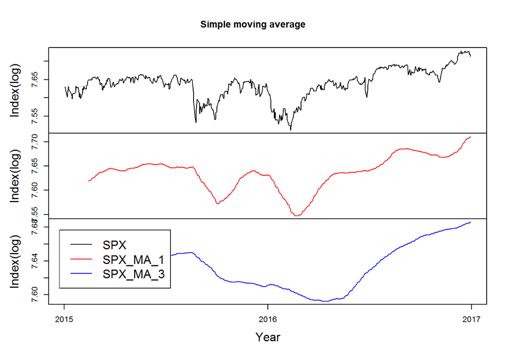

```r
SPX_MA_1 <- na.omit(rollapply(SPX_train, 30, FUN = mean, align = "right"))
SPX_MA_3 <- na.omit(rollapply(SPX_train, 90, FUN = mean, align = "right"))

plot.zoo(merge(merge(SPX_train, SPX_MA_1), SPX_MA_3), col = c("black", "red", "blue"),
         xlab = "Year", ylab = "Index(log)", main = "Simple moving average")
legend("bottomleft", c("SPX", "SPX_MA_1", "SPX_MA_3"), col = c("black", "red", "blue"), lty = 1)
```

## L2 filter

Generally we want our trend to follow the same movement of our time series data.

This is expressed in the function
$$\left\{\hat{x}_1,...,\hat{x}_n\right\}=\arg\min\frac{1}{2}\sum_{t=1}^{n}\left(y_t-\hat{x}_t\right)^2$$

However, we would like to impose some restrictions on our trend function so that it does not overfit to short-term, non-trend variations.

In L2 filter, we are trading-off between deviations from trend and smoothness of trend. An desirable trend attribute is that it moves along with the “big picture” of time series while less respondent to any short-term volatility.

In practice, first we assume the trend of return is a constant. Then we will have the system:
$$x_t = x_{t-1} + \mu\\y_t = \mu t + \epsilon_t$$

Then estimating the trend $\hat{x}_t$ is also equivalent to estimating the coefficient $\mu$
$$\hat{\mu}=\frac{\sum\nolimits_{t=1}^{n}ty_t}{\sum\nolimits_{t=1}^{n}t^2}$$

If we consider the $\mu$ is not constant, we can define the following objective function, as a tradeoff between errors and smoothness.
$$\frac{1}{2}\sum_{t=1}^{n}\left(y_t-\hat{x}_t\right)^2+\lambda\sum_{t=2}^{n-1}\left(\hat{x}_{t-1}-2\hat{x}_t+\hat{x}_{t+1}\right)^2$$

In vectorial form it is
$$\frac{1}{2}\left\lVert y-\hat{x} \right\rVert_2^2 + \lambda \left\lVert D\hat{x}\right\rVert_2^2$$

where
$$D=\left(
\begin{array}{cc}
1 & -2 & 1 & & & & &\\
& 1 & -2 & 1\\
& & & \ddots\\
&&&&1&-2&1\\
&&&&&1&2&1
\end{array}\right)$$

Then it can be rewritten as
$$\hat{x}=\left(I+2\lambda D^TD\right)^{-1}y$$

Solving this problem and we can have a restricted fitted line that represents trend of the L2 filter.

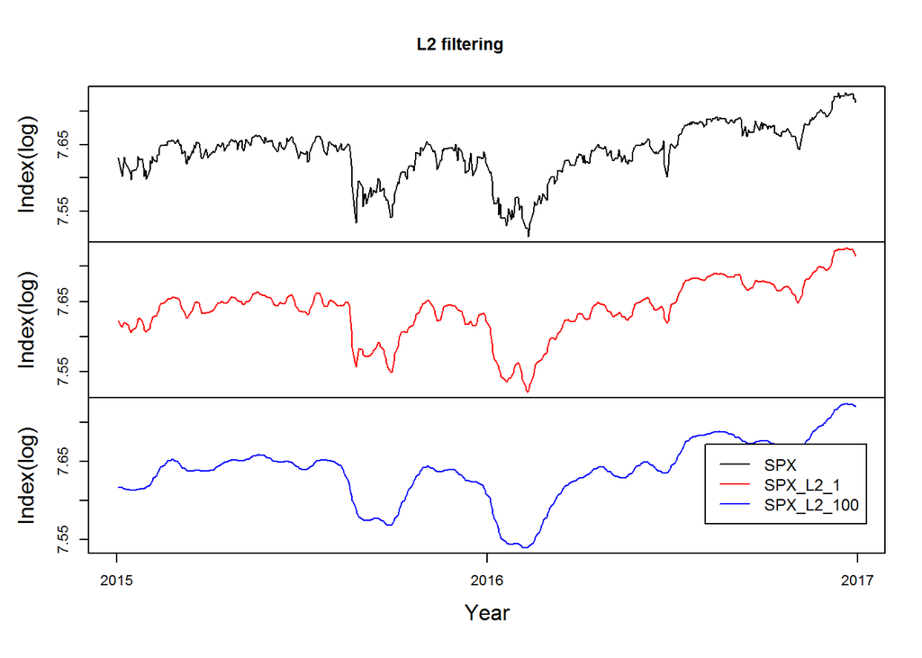

```r
l2filter.optim <- function(x, lambda = 0.0) {
  objective <- function(y, lambda) {
    n <- length(x)
    P1 = 0.5 * sum((y - x)**2)
    P2 = 0
    for (i in 2:(n-1)) {
        P2 = P2 + (y[i-1] - 2 * y[i] + y[i+1])**2
        }
    P1 + lambda * P2
    }
  optim(x, objective, lambda = lambda, method = "BFGS")$par
}

l2filter.matrix <- function(x, lambda = 0.0) {
  n <- length(x)

  I = diag(1, nrow = n)

  D = matrix(0, nrow = n - 2, ncol = n)
  #
  for (i in 1:(n-2)) {
    D[i, i:(i+2)] = c(1, -2, 1)
  }

  xts(c(solve(I + 2 * lambda * t(D) %*% D) %*% coredata(x)), index(x))
}

library(Matrix)

l2filter.sparse <- function(x, lambda = 0.0) {
  n <- length(x)

  I = Diagonal(n)

  D = bandSparse(n = n - 2, m = n, k = c(0, 1, 2),
                 diagonals = list(rep(1, n), rep(-2, n), rep(1, n)))

  xts((solve(I + 2 * lambda * t(D) %*% D) %*% coredata(x))[,1],  index(x))
}

library(zoo)
plot.zoo(merge(merge(SPX_train, l2filter.sparse(SPX_train, 1)),l2filter.sparse(SPX_train, 100)), col = c("black", "red", "blue"),
         xlab = "Year", ylab = "Index(log)", main = "L2 filtering")
legend("bottomright", c("SPX", "SPX_L2_1", "SPX_L2_100"), col = c("black", "red", "blue"), lty = 1, cex = 0.75)
```

## Kalman filter

The dynamic of the Kalman filter system can be expressed as
$$\begin{cases}R_t=\mu_t+\sigma_{\zeta}\zeta_t\\\mu_t=\mu_{t-1}+\sigma_{\eta}\eta_t\end{cases}$$

The trend of return itself is stochastic and autocorrelated, while the return adds another error term.

The estimation of $\mu_t$ can be defined as
$$\hat{\mu}_{t|t-1}=\mathbb{E}_{t-1}\left[\mu_t\right]$$

The variance of $\mu_t$, called $P_t$ is defined as
$$P_{t|t-1}=\mathbb{E}_{t-1}\left[\left(\hat{\mu}_{t|t-1}-\mu_t\right)^2\right]$$

Therefore we can define an update process that incorporates the latest information that
$$\hat{\mu}_{t+1|t}=(1-K_t)\hat{\mu}_{t|t-1}+K_tR_t$$
in which
$$K_t=\frac{P_{t|t-1}}{P_{t|t-1}+\sigma_{\zeta}^2}$$

In practice, we can use this method of solving the equation in this single-variate situation:
$$\hat{\mu}_{t+1|t}=(1-\kappa)\hat{\mu}_{t|t-1}+\kappa R_t$$

where$\kappa=\frac{2\sigma_{\eta}}{\sigma_{\eta}+\sqrt{\sigma_{\eta}^2+4\sigma_{\zeta}^2}}$

If we wrote the formula as this, we can set $\lambda =-\ln(1-\kappa)$

Then the prediction of this single time series can be rewritten as
$$\hat{\mu}_t =\left(1-e^{-\lambda}\right)\sum_{i=0}^{\infty} e^{-\lambda i} R_{t-i}$$
which is a exponential-weighted average.

And the trend of log-price can be written as
$$\hat{x}_t = \left(1-e^{-\lambda}\right)\sum_{i=0}^{\infty} e^{-\lambda i}y_{t-i}$$

Deriving first derivatives, we have
$$\hat{\mu}_t=\left(1-e^{-\lambda}\right) y_t - \left(1-e^{-\lambda}\right)\left(e^{\lambda}-1\right)\sum_{i=1}^{\infty}e^{-\lambda i} y_{t-i}$$

An example is listed as follows:

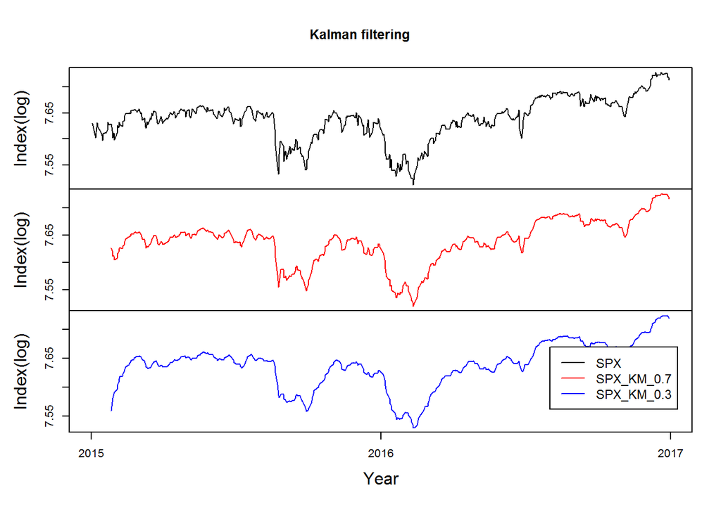

```r
kmfilter <- function(x, lambda = 0.0) {
  n <- length(x)
  xhat <- numeric(n)
  for(i in 1:n){
    xhat[i] <- (1 - exp(-lambda))*sum(exp(-lambda*((i-1):0))*x[1:i])
  }
  xts(xhat, index(x))[-(1:10)]
}
plot.zoo(merge(merge(SPX_train, kmfilter(SPX_train, 0.7)[-(1:5)]),kmfilter(SPX_train, 0.3)[-(1:5)]), col = c("black", "red", "blue"),
         xlab = "Year", ylab = "Index(log)", main = "Kalman filtering")
legend("bottomright", c("SPX", "SPX_KM_0.7", "SPX_KM_0.3"), col = c("black", "red", "blue"), lty = 1, cex = 0.75)
```

## Loess regression

For the local polynomial regressions like
$$\begin{align}y_t & \,=\, f(t) \,+\, \epsilon_t \\& \,=\, \beta_0(\tau) \,+\, \sum_{j=1}^{p}\beta_j(\tau)(\tau \, - t)^j \,+\,\epsilon_t\ \\\end{align}$$
they try to use basis functions with order more than 1 to fit some datasets that have no apparent relationship.

To avoid overfitting, loess regression first try to get the residuals $\hat{\epsilon_t}$, then compute $\delta_t \,=\, (1 - \mu_t^2) \cdot 1\{|\mu_t|\leq 1\}$ with $\mu_t = \hat{\epsilon}_t / (6\, \text{median}|\hat{\epsilon}|)$ and run a second kernel regression with weightings $\delta_t w_t$.

In this way it effectively underweights points that are far away from the mainstream “trend”.

An example shows further detail about it.

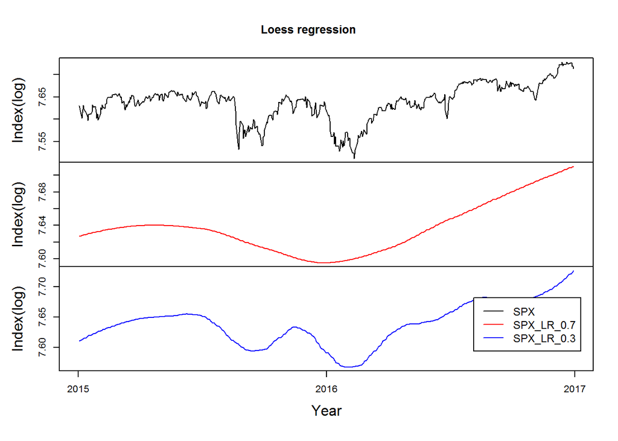

```r
y = coredata(SPX_train)
colnames(y) = "y"
x = 1:length(SPX_train)
da <- data.frame(cbind(y,x))
lw1 = loess(y~x, da, span = 0.7)
predict(lw1, 511)
lw2 = loess(y~x, da, span = 0.3)

plot.zoo(merge(merge(SPX_train, lw1$fitted),lw2$fitted), col = c("black", "red", "blue"),
         xlab = "Year", ylab = "Index(log)", main = "Loess regression")
legend("bottomright", c("SPX", "SPX_LR_0.7", "SPX_LR_0.3"), col = c("black", "red", "blue"), lty = 1, cex = 0.75)
```

## L1 filter

Similar to the L2 filter, and much like the LASSO regression, we now consider the L1 term to be a smoothness penalty function.

The objective function can then be written as
$$\frac{1}{2} \sum_{t=1}^{n} \left(y_t - \hat{x}_t\right)^2 \,+\,\lambda \sum_{t=2}^{n-1}\left|\hat{x}_{t-1}-2\hat{x}_t+\hat{x}_{t+1}\right|$$

The equivalent vectorial form is
$$\frac12 \left\lVert y-\hat{x} \right\rVert_2^2 \,+\,\lambda \left\lVert D\hat{x} \right\rVert_1$$

The inclusion of L1 term results in the fitted curve to be locally linear, resulting in kinks among differing local trends.

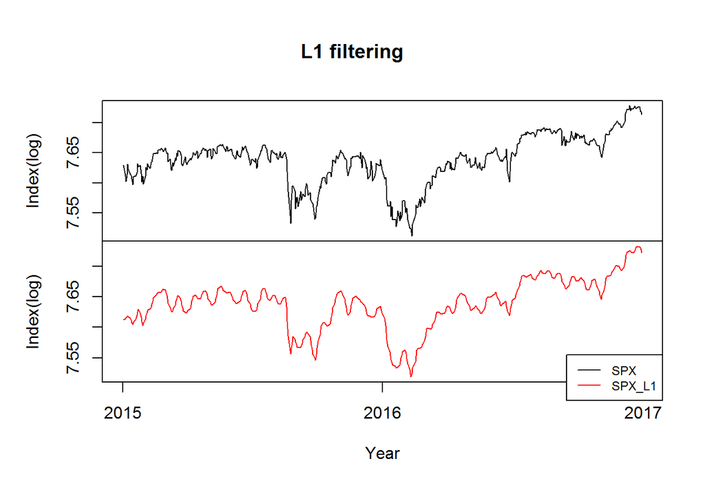

```r
# knitr::opts_chunk$set(echo = FALSE, warnings=FALSE, error = FALSE, message = FALSE)
# options(warn = 0)
l1filter.optim <- function (x, lambda = 0.0) {
  objective <- function(y, lambda) {
    n <- length(x)

    P1 = 0.5 * sum((y - coredata(x))**2)
    #
    P2 = 0
    for (i in 2:(n-1)) {
      P2 = P2 + abs(y[i-1] - 2 * y[i] + y[i+1])
    }
    #
    P1 + lambda * P2
  }
  #
  fit = optim(x, objective, lambda = lambda, method = "CG", control = list(maxit = 100000, type = 3))

  if (fit$convergence != 0) {
    warning(sprintf("Optimisation failed to converge! (lambda = %f)", lambda))
    print(fit)
  }

  return(fit$par)
}
l1 <- l1filter.optim(SPX_train, 0.5)

plot.zoo(merge(SPX_train, l1), col = c("black", "red"),
         xlab = "Year", ylab = "Index(log)", main = "L1 filtering")
legend("bottomright", c("SPX", "SPX_L1"), col = c("black", "red"), lty = 1, cex = 0.75)
```

## Wavelet filter

Wavelet filter originates from Fourier transformation.

The Fourier transformation allows us to consider original signal as a combination of frequency functions
$$y(\omega)=\sum_{t=1}^n y_t e^{-iwt}$$
It decomposes time serieses into some cyclical functions.

However they face difficulties when trends reverse from one specific period to another.

To avoid difficulties when trend reverses, we will have Wavelet filter, which takes into consideration both frequency and time.

The process of Wavelet function generally follows:

1. First we compute the wavelet transformation $\mathcal W$ of $y_t$ and get wavelet coefficients $\omega = \mathcal W(y)$
2. We apply a denoising rule $D$:
   $$\omega^* = D(\omega)$$
3. Use the inverse Wavelet transformation $\mathcal W^{-1}$ we get
   $$x=\mathcal W^{-1}\left(\omega^*\right)$$

Let $\omega^-$, $\omega^+$ be two scalars with $0<\omega^-<\omega^+$

The shrinkage methods includes:

- Hard Shrinkage

$$\omega_i^* = \omega_i \cdot \mathbb{1}\left\{ \left|\omega_i\right| > \omega^+ \right\}$$

- Soft Shrinkage

$$\omega_i^* = \text{sgn}(\omega_i) \cdot \left( \left|\omega_i\right| - \omega^+ \right)_+$$

- Semi-soft shrinkage

$$\omega_i^* =
\begin{cases}
0 & \, |\omega_i| \leq \omega^-\\
\text{sgn}(\omega_i)(\omega^+-\omega^-)^{-1}\omega^+(|\omega_i|-\omega^-) & \,\, \omega^-<|\omega_i| \leq \omega^+ \\
\omega_i & \, |\omega_i| > \omega^+
\end{cases}$$

- Quantile shrinkage is a hard shrinkage method where $\omega^+$ is the $q^{th}$ quantile of the coefficients $|\omega_i|$

An example of the Wavelet method is:

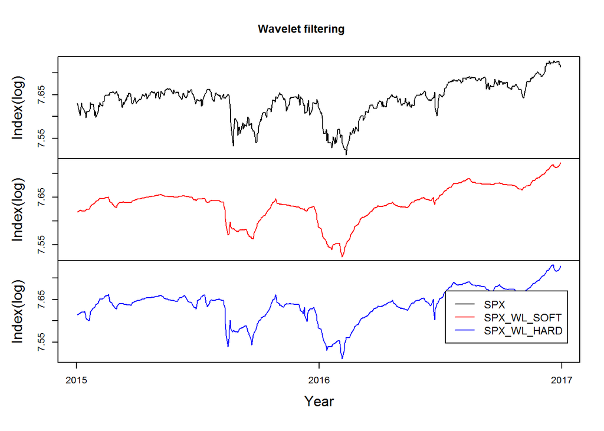

```r
# knitr::opts_chunk$set(echo = FALSE, warnings=FALSE, error = FALSE, message = FALSE)
# suppressPackageStartupMessages(library(wavethresh))
library(wavethresh)
options(warn = 0)

 Time <- 1:length(SPX_train)
 Accel <- coredata(SPX_train)
#
# Rescale Time to [0,1]

 Time01 <- (Time - min(Time))/(max(Time) - min(Time))
#
# Interpolate data to grid
#
 McycleGrid <- makegrid(t=Time01, y=Accel)
#
# Scale new [0,1] grid back to original scale
#
 TimeGrid<-McycleGrid$gridt*(max(Time)-min(Time))+min(Time)
#
# Plot interpolated data
#
 # lines(TimeGrid, McycleGrid$gridy)
# Perform KS00 irregular wavelet transform
#
 McycleIRRWD <- irregwd(McycleGrid)
#
# Convert the irregwd object to wd for coef plotting
#
 McycleIRRWD2 <- McycleIRRWD
 class(McycleIRRWD2) <- "wd"
 # plot(McycleIRRWD2)
# Do thresholding
#
 McycleT <- threshold(McycleIRRWD, policy="universal",type="soft", dev=madmad)
#
# Invert and plot, and original
#
 McycleT1 <- threshold(McycleIRRWD, policy="universal",type="soft", dev=madmad)
 McycleT2 <- threshold(McycleIRRWD, policy="universal",type="hard", dev=madmad)
#
# Invert and plot, and original
#
 McycleWR1 <- wr(McycleT1)
 McycleWR2 <- wr(McycleT2)
 plot.zoo(merge(merge(SPX_train, McycleWR1[-(1:8)]),McycleWR2[-(1:8)]), col = c("black", "red", "blue"),
          xlab = "Year", ylab = "Index(log)", main = "Wavelet filtering")
 legend("bottomright", c("SPX", "SPX_WL_SOFT", "SPX_WL_HARD"), col = c("black", "red", "blue"), lty = 1, cex = 0.75)
```

## Get the best parameter: Moving Average

We want to determine the best moving average window to predict future market prices.

The cross-validation gives little hint about moving average, since the shorter-term moving average almost surely closer to the actual data and produces less errors.

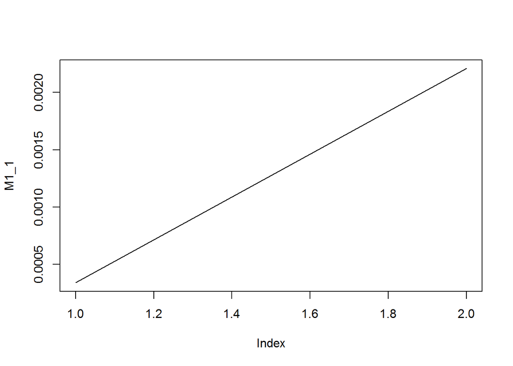

```r
M1_1 <- sapply(c(30, 90), function(x){
  series <- sapply(504:545, function(y){
    ts <- na.omit(rollapply(SPX[1:y], x, FUN = mean, aligh = "right"))
    2*last(ts) - last(ts, 2)
  })
  sum((SPX_test - series)^2) /41
})
plot(M1_1, type = "l")
```

```r
which.min(M1_1) #n = 30
```

```
## [1] 1
```

## Get the best parameter: L2

For L2 term we try to get the best lambda. The best lambda is therefore 0.06.

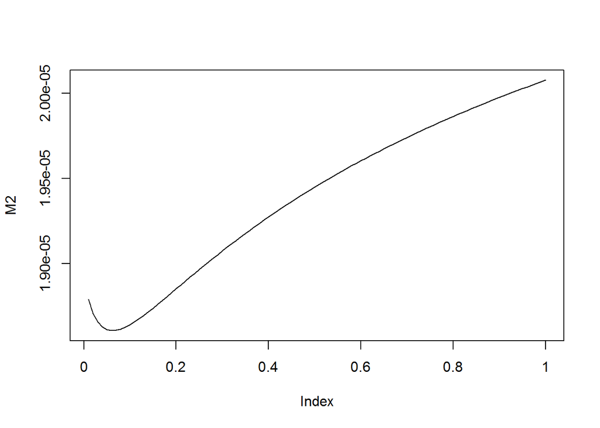

```r
library(Matrix)

l2filter.sparse <- function(x, lambda = 0.0) {
  n <- length(x)

  I = Diagonal(n)

  D = bandSparse(n = n - 2, m = n, k = c(0, 1, 2),
                 diagonals = list(rep(1, n), rep(-2, n), rep(1, n)))

  xts((solve(I + 2 * lambda * t(D) %*% D) %*% coredata(x))[,1],  index(x))
}

M2 <- sapply(seq(0.01,1,0.01), function(x){
  series <- sapply(504:545, function(y){
    ts <- l2filter.sparse(SPX[1:y], lambda = x)
    last(ts)*2 - last(ts, 2)
  })
  sum((SPX_test - series)^2)/41
})

# M2_1 <- sapply(seq(0.01,1,0.01), function(x){ sum((SPX_test -
#                                             sapply(504:545, function(y) last(l2filter.sparse(SPX[1:y], lambda = x))))^2)/41
# })
plot(M2, type = "l", xaxt = "n")
axis(1, at = seq(0, 100, 20), labels = seq(0, 100, 20)/100)
```

```r
which.min(M2) #lambda = 0.06
```

```
## [1] 6
```

## Get the best parameter: Kalman filter

With Kalman filter we would like to get the best lambda through time series cross validation as well.

In this case the optimal lambda value is 0.12.

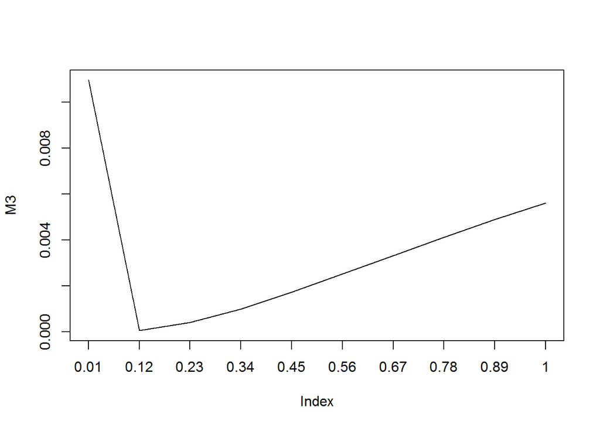

```r
kmfilter <- function(x, lambda = 0.0) {
  n <- length(x)
  xhat <- numeric(n)
  for(i in 1:n){
    xhat[i] <- (1 - exp(-lambda))*sum(exp(-lambda*((i-1):0))*x[1:i])
  }
  xts(xhat, index(x))[-(1:10)]
}

M3 <- sapply(seq(0.01, 1, length.out = 10), function(x){
  series <- sapply(504:545, function(y){
    tss <- kmfilter(SPX[1:y], lambda = x)
    coredata(last(tss)) * (2 - exp(-x)) - sum((1-exp(-x))*(exp(x)-1)*exp(-x * 1:y) * coredata(SPX[1:y]))
  })
  sum((SPX_test - series)^2)/41
})
plot(M3, type = "l", xaxt = "n")
axis(1, at = 1:10, labels = seq(0.01, 1, length.out = 10))
```

```r
which.min(M3) # lambda 0.12
```

```
## [1] 2
```

## Get the best parameter: Loess regression

In loess regression, the lambda controls degree of freedom for local polynomials. The lambda is set to 0.02.

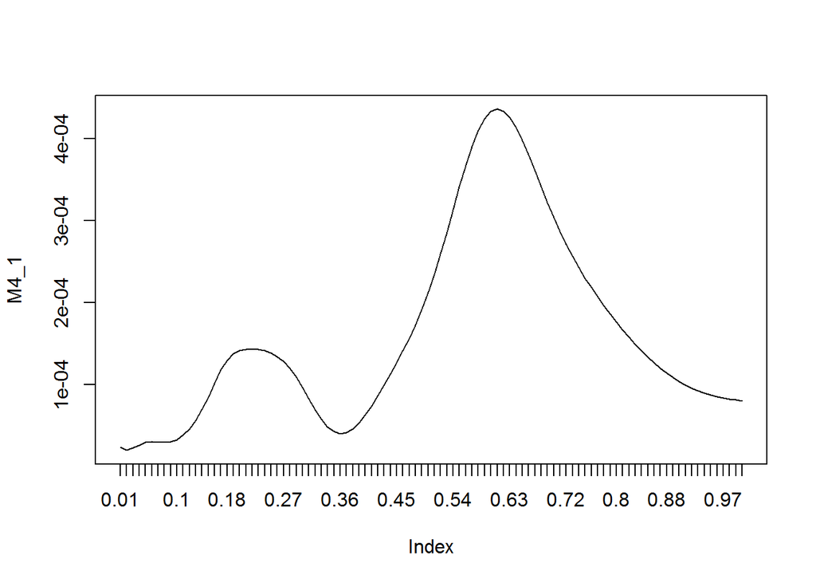

```r
loessown <- function(x, lambda = 0.0){
  da <- data.frame(cbind(coredata(x),1:length(x)))
  names(da) <- c("y", "x")
  last(loess(y~x, da, span = lambda)$fitted)
}

M4_1 <- sapply(c(seq(0.01, 1, by = 0.01)), function(x){ sum((SPX_test - sapply(504:545, function(y) last(loessown(SPX[1:y], lambda = x))))^2)/41})

plot(M4_1, type = "l", xaxt = "n")
axis(1, at = 1:100, labels = seq(0.01, 1, by=0.01))
```

```r
which.min(M4_1) # lambda = 0.02
```

```
## [1] 2
```

## Get the best parameter: L1 filter

For the L1 filter, it we set the error term to minimum, clearly lambda term should be minimum.

In the following example, we choose 0.001 as the optimal lambda.

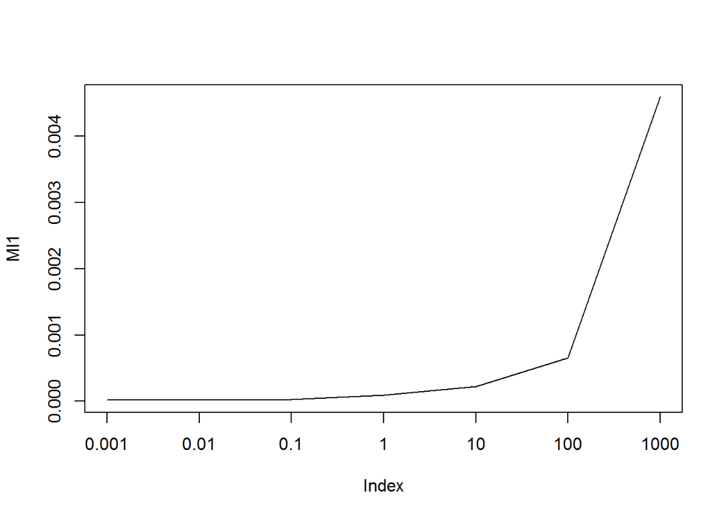

```r
library(l1tf)

l1fs <- function(x, lambda = 0.0){
  da <- x
  fitted <- l1tf(da, lambda = lambda)
  last(fitted)*2 - last(fitted, 2)
}

Ml1 <- sapply(10^(-3:3), function(x){ sum((SPX_test -
                                                 sapply(504:545, function(y) last(l1fs(SPX[1:y], lambda = x))))^2)/41
})
# Ml1 <- sapply(10^(-3:3), function(x){
#   pred <- sapply(504:545, function(y){l1fs(SPX[1:y], lambda = x)})
#   sum((SPX_test - pred)^2)
# })

plot(Ml1, type = "l", xaxt = "n")
axis(1, at = 1:7, labels = 10^(-3:3))
```

```r
which.min(Ml1) # lambda = 0.001
```

[output not shown]

## Get the best parameter: Wavelet

For Wavelet transformation, we want to make sure which kind of shrinkage methods yields the best trends for prediction.

Based on the findings below, we choose the “soft” threshold.

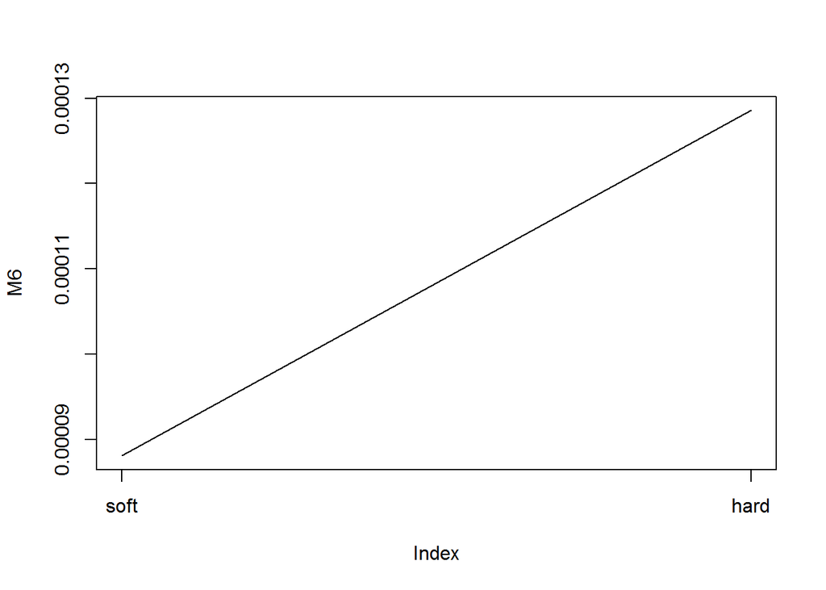

```r
library(wavethresh)

waveletown <- function(x, rule = "soft"){
  Time <- 1:length(x)
  Accel <- coredata(x)
  Time01 <- (Time - min(Time))/(max(Time) - min(Time))
  McycleGrid <- makegrid(t=Time01, y=Accel)
  TimeGrid<-McycleGrid$gridt*(max(Time)-min(Time))+min(Time)
  McycleIRRWD <- irregwd(McycleGrid)
  McycleIRRWD2 <- McycleIRRWD
  class(McycleIRRWD2) <- "wd"
  McycleT1 <- threshold(McycleIRRWD, policy="universal",type=rule, dev=madmad)
  last(wr(McycleT1))
}
M6 <- sapply(c("soft", "hard"), function(x){ sum((SPX_test -
                                            sapply(504:545, function(y) last(waveletown(SPX[1:y], rule = x))))^2)/41
})
plot(M6, type = "l", xaxt = "n")
axis(1, at = 1:2, labels = c("soft", "hard"))
```

## Trading strategy based on trend

We implement filters with optimal parameters that we’ve discussed so far and examine the result.

A result of five filter strategy is listed.

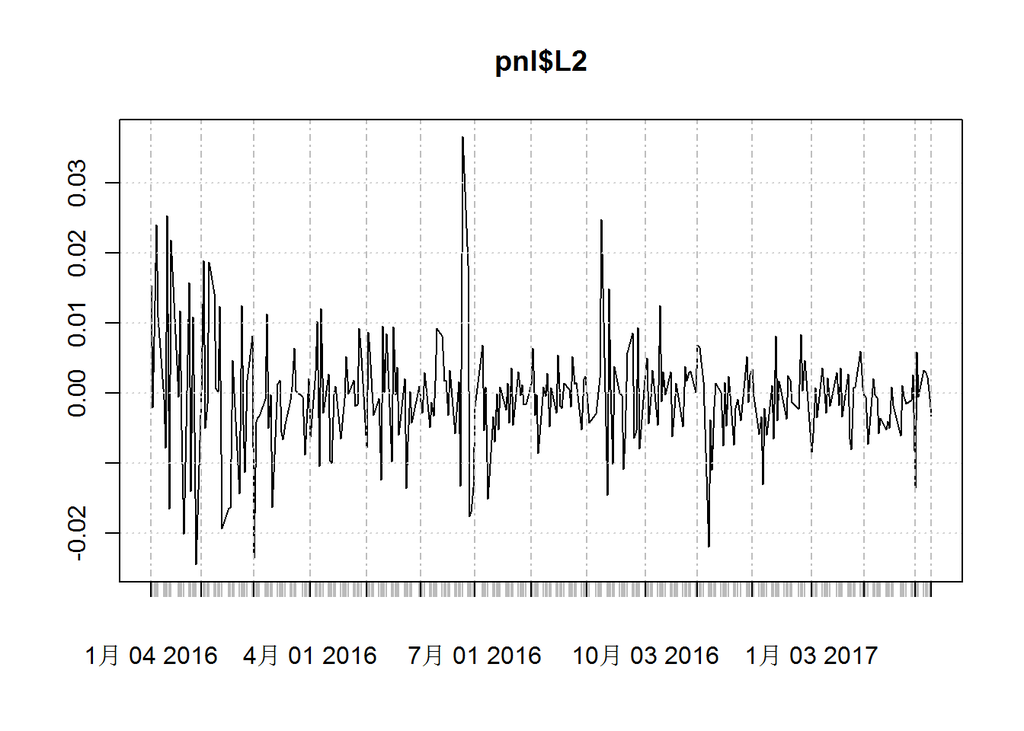

```r
SP <- log(Quandl("YAHOO/INDEX_GSPC", type = "xts", start_date="2008-01-01", end_date ="2017-03-10")$Adj)

#strategy, when the trend is upward we buy otherwise we sell
real <- SP[2015:2313]
fore <- list()
fore$SMA <- ifelse(sapply(2015:2313, function(y) last(na.omit(rollapply(SP[1:y],30, FUN = mean, align = "right"))))>real, 1, -1)

l2pred <- sapply(2015:2313, function(y){
    ts <- l2filter.sparse(SP[1:y], lambda = 0.06)
    last(ts) - last(ts, 2)
  })
fore$L2 <- ifelse(l2pred>0, 1, -1)

kalpred <- sapply(2015:2313, function(y){
    tss <- kmfilter(SP[1:y], lambda = 0.12)
    coredata(last(tss)) * (1 - exp(-0.12)) - sum((1-exp(-0.12))*(exp(0.12)-1)*exp(-0.12 * 1:y) * coredata(SP[1:y]))
  })
fore$Kalman <- ifelse(kalpred > 0, 1, -1)

# modify a little about the loess function
loessown1 <- function(x, lambda = 0.0){
  da <- data.frame(cbind(coredata(x),1:length(x)))
  names(da) <- c("y", "x")
  vec <- loess(y~x, da, span = lambda)$fitted
  last(vec) - last(vec, 2)[1]
}

loepred <- sapply(2015:2313, function(y) last(loessown1(SP[1:y], lambda = 0.02)))
fore$Loess <- ifelse(loepred > 0, 1, -1)

# modify to get the slope from L1 result
l1fs1 <- function(x, lambda = 0.0){
  da <- coredata(x)
  fitted <- l1tf(da, lambda = lambda)
  last(fitted) - last(fitted, 2)[1]
}
l1pred <- sapply(2015:2313, function(y) last(l1fs1(SP[1:y], lambda = 0.001)))
fore$L1 <- ifelse(l1pred > 0, 1, -1)

# modify to get the slope as wavelet's trend prediction
waveletown1 <- function(x, rule = "soft"){
  Time <- 1:length(x)
  Accel <- coredata(x)
  Time01 <- (Time - min(Time))/(max(Time) - min(Time))
  McycleGrid <- makegrid(t=Time01, y=Accel)
  TimeGrid<-McycleGrid$gridt*(max(Time)-min(Time))+min(Time)
  McycleIRRWD <- irregwd(McycleGrid)
  McycleIRRWD2 <- McycleIRRWD
  class(McycleIRRWD2) <- "wd"
  McycleT1 <- threshold(McycleIRRWD, policy="universal",type=rule, dev=madmad)
  last(wr(McycleT1)) - last(wr(McycleT1), 2)[1]
}
wavpred <- sapply(2015:2313, function(y) last(waveletown1(SP[1:y], rule = "soft")))
fore$Wavelet <- ifelse(wavpred > 0, 1, -1)

pnl <- list()

pnl$L2 <- na.omit(diff(SP[2015:2314]))*fore$L2
plot(pnl$L2)
```

```r
sum(pnl$L2)
```

```
## [1] -0.1491072
```

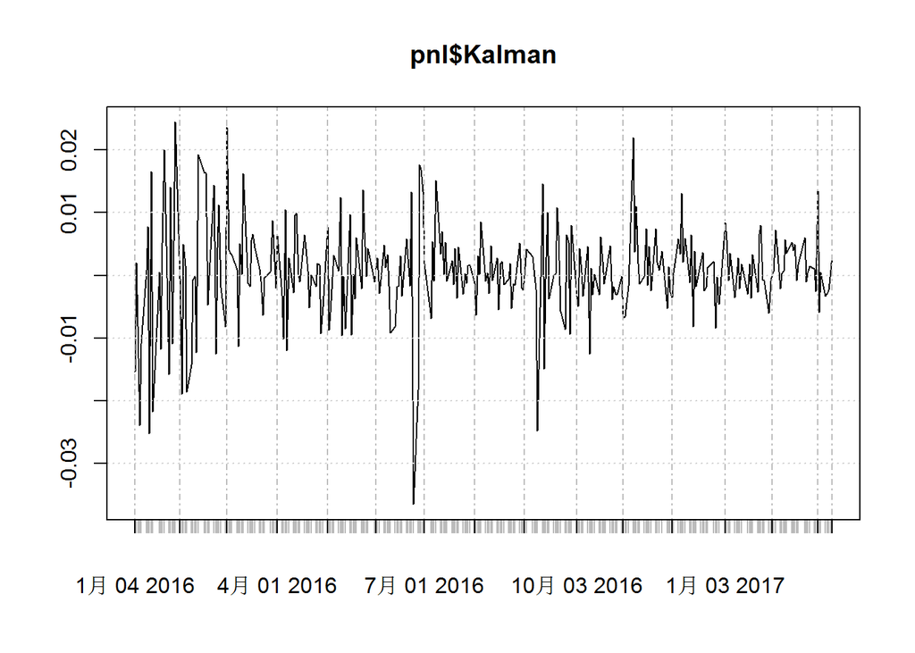

```r
pnl$Kalman <- na.omit(diff(SP[2015:2314]))*fore$Kalman
plot(pnl$Kalman)
```

```r
sum(pnl$Kalman)
```

```
## [1] 0.1491072
```

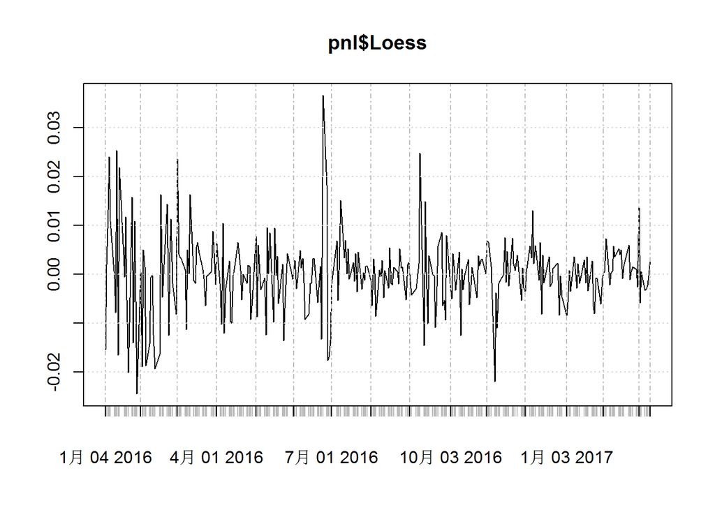

```r
pnl$Loess <- na.omit(diff(SP[2015:2314]))*fore$Loess
plot(pnl$Loess)
```

```r
sum(pnl$Loess)
```

```
## [1] -0.01815445
```

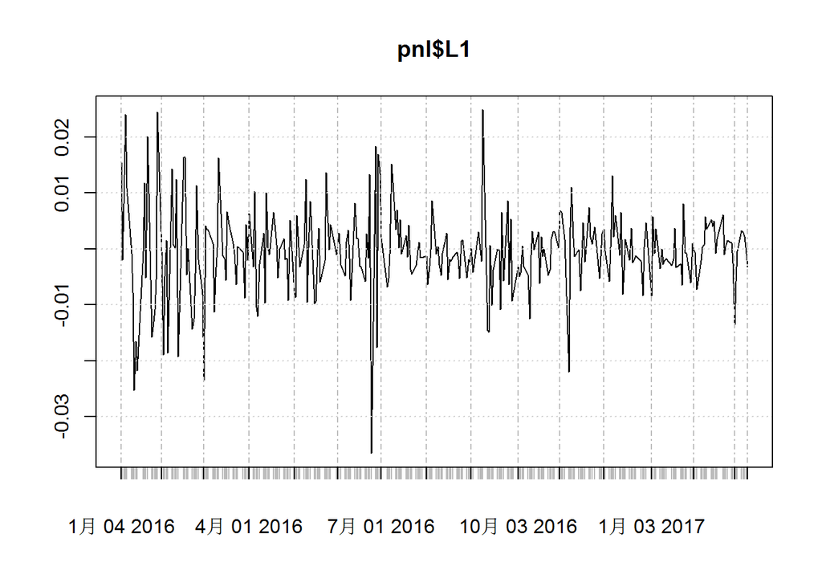

```r
pnl$L1 <- na.omit(diff(SP[2015:2314]))*fore$L1
plot(pnl$L1)
```

```r
sum(pnl$L1)
```

```
## [1] -0.1710458
```

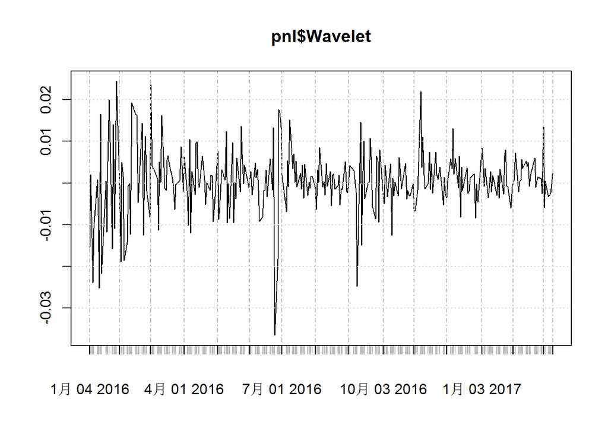

```r
pnl$Wavelet <- na.omit(diff(SP[2015:2314]))*fore$Wavelet
plot(pnl$Wavelet)
```

```r
sum(pnl$Wavelet)
```

```
## [1] 0.1335621
```

```r
# calculate the parameters of each trading results
hits <- c(L2 = sum(pnl$L2 > 0)/length(pnl$L2), Kalman = sum(pnl$Kalman > 0)/length(pnl$Kalman),
          Loess = sum(pnl$Loess > 0)/length(pnl$Loess), L1 = sum(pnl$L1 > 0)/length(pnl$L1),
          Wavelet = sum(pnl$Wavelet > 0)/length(pnl$Wavelet))
dayswin <- c(L2 = sum(pnl$L2 > 0), Kalman = sum(pnl$Kalman > 0),
          Loess = sum(pnl$Loess > 0), L1 = sum(pnl$L1 > 0),
          Wavelet = sum(pnl$Wavelet > 0))
dayslose <- c(L2 = sum(pnl$L2 < 0), Kalman = sum(pnl$Kalman < 0),
          Loess = sum(pnl$Loess < 0), L1 = sum(pnl$L1 < 0),
          Wavelet = sum(pnl$Wavelet < 0))
win <- c(L2 = mean(pnl$L2[pnl$L2 > 0]), Kalman = mean(pnl$Kalman[pnl$Kalman > 0]),
          Loess = mean(pnl$Loess[pnl$Loess > 0]), L1 = mean(pnl$L1[pnl$L1 > 0]),
          Wavelet = mean(pnl$Wavelet[pnl$Wavelet > 0]))
lose <- c(L2 = mean(pnl$L2[pnl$L2 < 0]), Kalman = mean(pnl$Kalman[pnl$Kalman < 0]),
          Loess = mean(pnl$Loess[pnl$Loess < 0]), L1 = mean(pnl$L1[pnl$L1 < 0]),
          Wavelet = mean(pnl$Wavelet[pnl$Wavelet < 0]))

rest <- cbind(hits, dayswin, dayslose, win, lose)

library(knitr)
kable(rest)
```

|  | hits | dayswin | dayslose | win | lose |
| --- | --- | --- | --- | --- | --- |
| L2 | 0.4648829 | 139 | 159 | 0.0052220 | -0.0055029 |
| Kalman | 0.5317726 | 159 | 139 | 0.0055029 | -0.0052220 |
| Loess | 0.5317726 | 159 | 139 | 0.0049770 | -0.0058237 |
| L1 | 0.4381271 | 131 | 167 | 0.0054572 | -0.0053050 |
| Wavelet | 0.5284281 | 158 | 140 | 0.0054886 | -0.0052402 |

## Refrences

[1] TREND FILTERING METHODS FOR MOMENTUM STRATEGIES, Benjamin Bruder et al, Lyxor Asset Management

[2] Understanding Extended Kalman Filter – Part II: Multi-dimensional Kalman Filter, Shudong Huang, University of Technology Sydney

[3] Wavelet Methods in Statistics with R,